# Multilevel data

MACS 30200 University of Chicago

May 15, 2017

# What influences partisan defection in voters?

- Partisan defection
- Potential explanations
  - Partisan intensity
  - Relative favorability
  - Correct is defect
  - Incumbency

# Pooling

- Pooling
- Requirements to pool
- Reasons for pooling
  - Pooling adds data
  - Generalizability
  - Readability

# Issues with pooling

$$\begin{align}
Pr(Y_{ei} = 1) &= \text{logit}^{-1}[\alpha + \beta_{1}\text{PID Intensity}_{ei} + \beta_{2}{\text{Relative Favorability}_{ei}} \nonumber \\
&\: + \beta_{3}\text{Defect is Correct}_{ei} + \beta_{4}\text{Incumbent Candidate}_{ei}] \nonumber \\
\text{logit}^{-1}[x] &= \frac{e^x}{1+e^x}
\end{align}$$

$$\mathbf{E} \in \{1972 ,\dotsc, 2008 \}$$

- Exchangability
  - that the process governing the relationship between $X$ and $Y$ is exactly the same for each $e$,
  - that the process governing the relationship between $X$ and $Y$ is the same for all $i$,
  - that the process governing the $u$s is the same $\forall \: e$ and $i$ as well.
- Violating exchangability assumption
  - Biased estimator

# The error term

$$u_{ij} \sim i.i.d.N(0, \sigma^2), \: \forall\: i,j$$

$$\begin{align}
Var(u_{ab}) &= Var(u_{cb}) \: \forall \: a \neq b \text{ (i.e., no cross-unit heteroscedasticity)}, \\
Var(u_{ab}) &= Var(u_{ac}) \: \forall \: b \neq c \text{ (i.e., no temporal heteroscedasticity)}, \\
Cov(u_{ab},u_{cd}) &= 0 \: \forall \: a \neq c,\: \forall \: b \neq d \text{ (i.e., no auto- or spatial correlation)}
\end{align}$$

- Assumption violations
  - Cross-unit differences
  - Time effects
  - Omitted variables

# Simulation of bad pooling

$$\begin{align}
y_{i} &\sim N(\alpha_{j[i]} + \beta x_{i},\sigma^2_y), &\text{for } i=1,\dotsc,n \nonumber \\
\alpha_j &\sim N(\mu_{\alpha},\sigma^2_{\alpha}), &\text{for } j=1,\dotsc,J
\end{align}$$

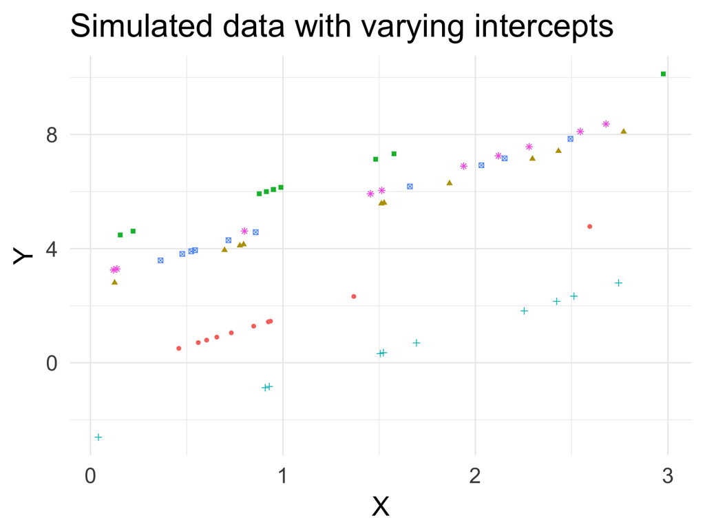

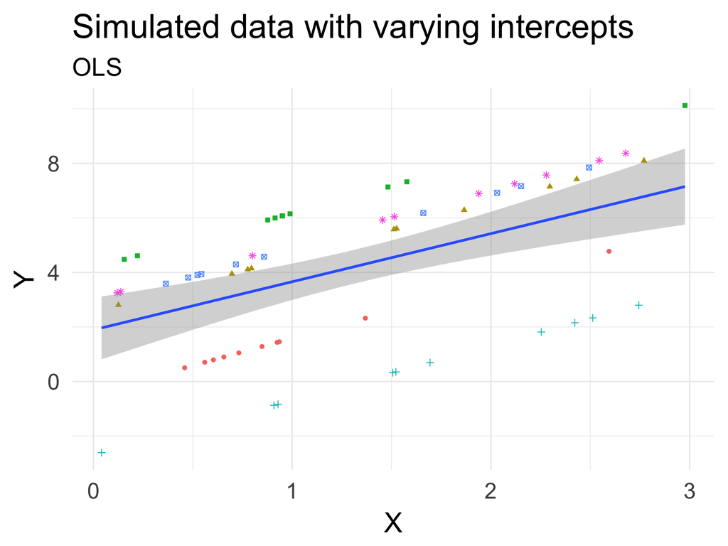

# Partisan defection and pooling

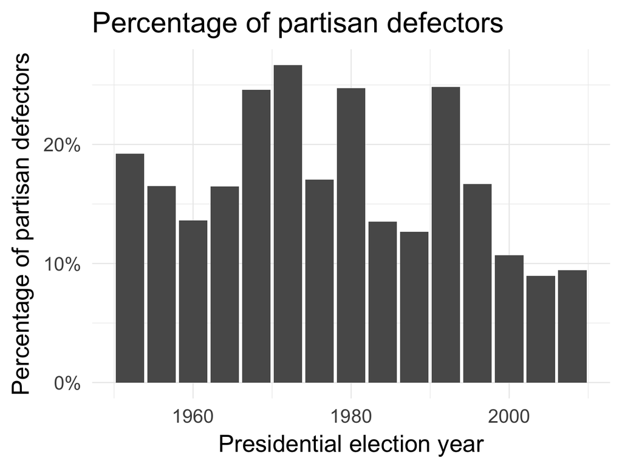

# Multilevel data structures

$$y_{i} \sim N(\alpha + \beta x_{i}, \sigma^2_{y}), \: \text{for}\: i=1,\dotsc,n$$

$$y_{ij} \sim N(\alpha + \beta x_{ij}, \sigma^2_{y}), \: \text{for}\: i=1,\dotsc,n; j = 1, \dotsc,k$$

- Assumes
  - Constant term is constant across different $i$s
  - Effect of any given variable $X$ on $Y$ is constant across observations

# Variable intercepts

$$y_{ij} \sim N(\alpha_i + \beta x_{ij}, \sigma^2_{y}), \: for\: i=1,\dotsc,n$$

$$y_{ij} \sim N(\alpha_t + \beta x_{ij}, \sigma^2_{y}), \: for\: i=1,\dotsc,n$$

# Variable slopes

$$y_{it} \sim N(\alpha + \beta_{i} x_{ij}, \sigma^2_{y}), \: for\: i=1,\dotsc,n$$

# Variable slopes and intercepts

$$y_{ij} \sim N(\alpha_{i} + \beta_{i} x_{ij}, \sigma^2_{y}), \: for\: i=1,\dotsc,n$$

$$y_{ij} \sim N(\alpha_{t} + \beta_{j} x_{ij}, \sigma^2_{y}), \: for\: i=1,\dotsc,n$$

$$y_{ij} \sim N(\alpha_{it} + \beta_{it} x_{ij}, \sigma^2_{y}), \: for\: i=1,\dotsc,n$$

# Multilevel modeling

- Random effects
- Fixed effects

# Fixed effects

- $J-1$ dummy variables
- When to use it

# Fixed effects

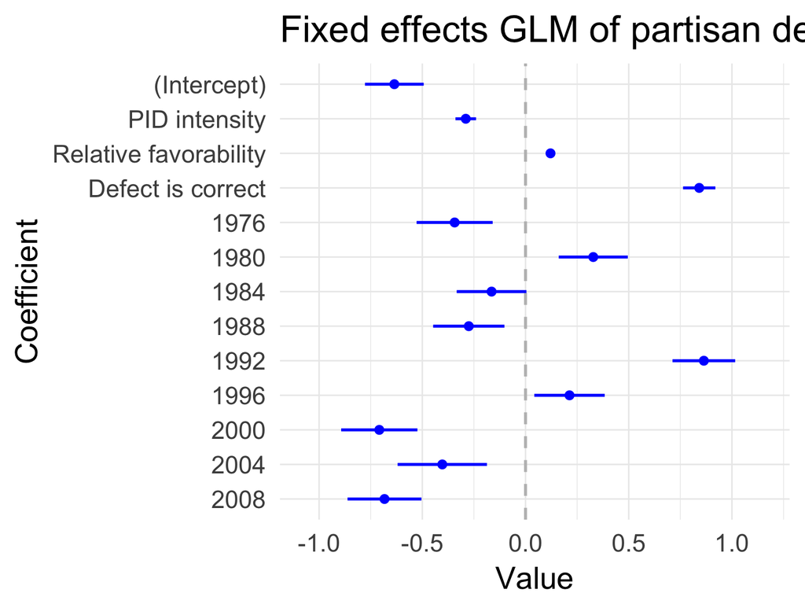

# Fixed effects fail

```
##
## Call:
## glm(formula = defect ~ pid_abs + feel_def + defect_cor + inc +
##     factor(year), family = binomial(link = "logit"), data = anes)
##
## Deviance Residuals:
##    Min      1Q  Median      3Q     Max
## -3.089  -0.403  -0.188  -0.065   3.527
##
## Coefficients: (1 not defined because of singularities)
##                  Estimate Std. Error z value Pr(>|z|)
## (Intercept)      -1.31876    0.13258   -9.95  < 2e-16 ***
## pid_abs          -0.28948    0.04995   -5.80  6.8e-09 ***
## feel_def          0.12097    0.00324   37.32  < 2e-16 ***
## defect_cor        0.84148    0.07826   10.75  < 2e-16 ***
## inc               0.68320    0.17907    3.82  0.00014 ***
## factor(year)1976 -0.34340    0.18432   -1.86  0.06244 .
## factor(year)1980  0.32818    0.16738    1.96  0.04992 *
## factor(year)1984 -0.16445    0.16889   -0.97  0.33020
## factor(year)1988  0.40838    0.16883    2.42  0.01557 *
## factor(year)1992  0.86387    0.15178    5.69  1.3e-08 ***
## factor(year)1996  0.21304    0.17052    1.25  0.21153
## factor(year)2000 -0.02518    0.18129   -0.14  0.88953
## factor(year)2004 -0.40321    0.21648   -1.86  0.06252 .
## factor(year)2008       NA         NA      NA       NA
## ---
## Signif. codes:  0 '***' 0.001 '**' 0.01 '*' 0.05 '.' 0.1 ' ' 1
##
## (Dispersion parameter for binomial family taken to be 1)
##
##     Null deviance: 9118.6  on 10380  degrees of freedom
## Residual deviance: 5164.6  on 10368  degrees of freedom
##   (7842 observations deleted due to missingness)
## AIC: 5191
##
## Number of Fisher Scoring iterations: 6
```

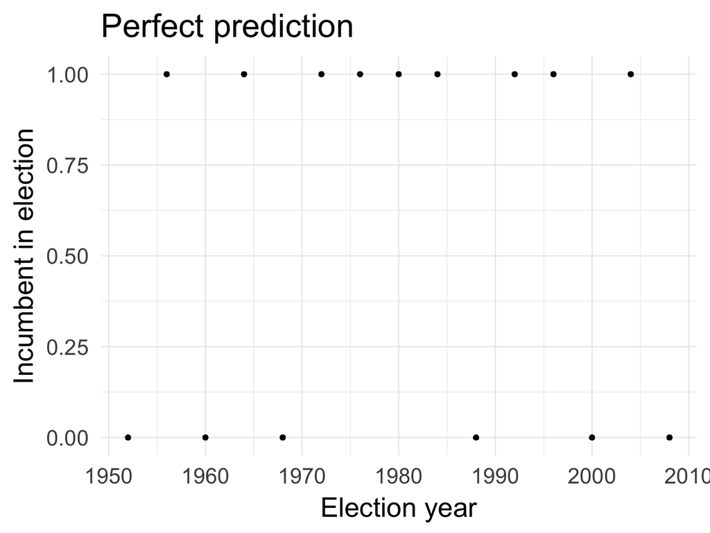

```
## # A tibble: 15 x 2
##     year   cor
##    <dbl> <lgl>
##  1  1952    NA
##  2  1956    NA
##  3  1960    NA
##  4  1964    NA
##  5  1968    NA
##  6  1972    NA
##  7  1976    NA
##  8  1980    NA
##  9  1984    NA
## 10  1988    NA
## 11  1992    NA
## 12  1996    NA
## 13  2000    NA
## 14  2004    NA
## 15  2008    NA
```

# Random effects

- Complete pooling
- No pooling
- Partial pooling
- Soft constraint
  - Probability distribution

# Varying intercepts

$$\begin{align}
y_i &\sim N(\alpha_{j[i]} + \beta x_{i}, \sigma^2_{y}), \: \text{for} \: i=1,\dotsc,n, \nonumber \\
\alpha_{j} &\sim N(\mu_{\alpha},\sigma^2_{\alpha}), \: \text{for} \: j=1,\dotsc,J,
\end{align}$$

- Partial-pooling
  - $\sigma_{\alpha} \to \infty$
  - $\sigma_{\alpha} \to 0$
- Reduces number of parameters

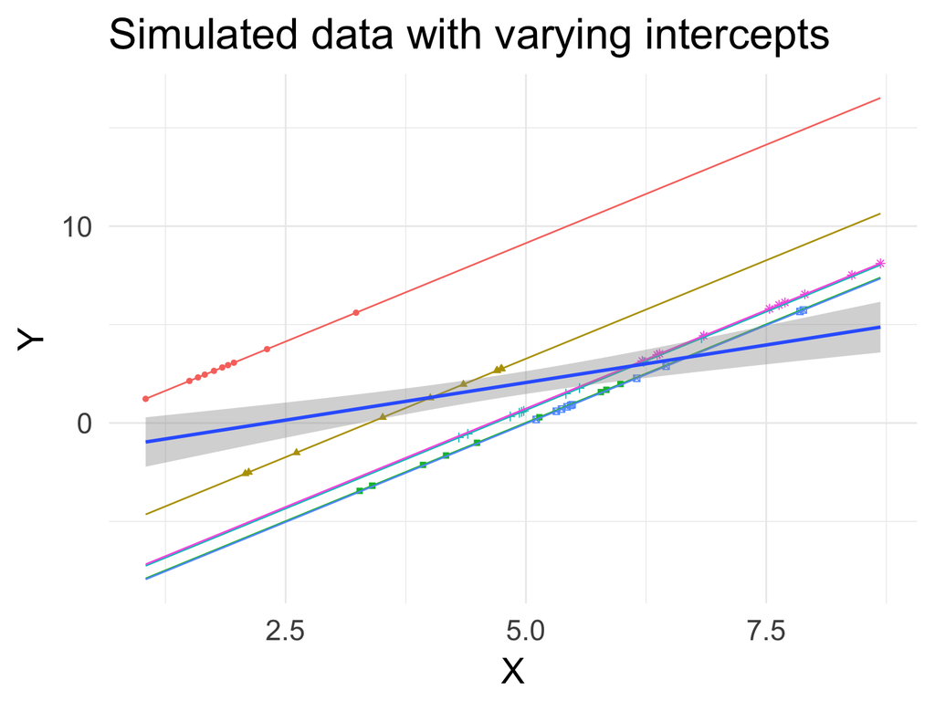

# Adding group-level predictors

$$\begin{align}
y_i &\sim N(\alpha_{j[i]} + \beta x_{i}, \sigma^2_{y}), \: \text{for} \: i=1,\dotsc,n, \nonumber \\
\alpha_{j} &\sim N(\gamma_{0} + \gamma_{1}u_{j},\sigma^2_{\alpha}), \: \text{for} \: j=1,\dotsc,J,
\end{align}$$

- Interpreting $\gamma$s

# Varying slopes

$$\begin{align}
y_i &\sim N(\alpha_{j[i]} + \beta_{j[i]} x_{i}, \sigma^2_{y}), \: \text{for} \: i=1,\dotsc,n, \nonumber \\
\begin{pmatrix}
\alpha_{j} \\
\beta_{j} \\
\end{pmatrix} &\sim N\left(\begin{pmatrix}
\mu_{\alpha} \\
\mu_{\beta} \\
\end{pmatrix},\begin{pmatrix}
\sigma^2_{\alpha} & \rho \sigma_{\alpha} \sigma_{\beta} \\
\rho \sigma_{\alpha} \sigma_{\beta} & \sigma^{2}_{\beta} & \\
\end{pmatrix}\right), \: \text{for} \: j=1,\dotsc,J,
\end{align}$$

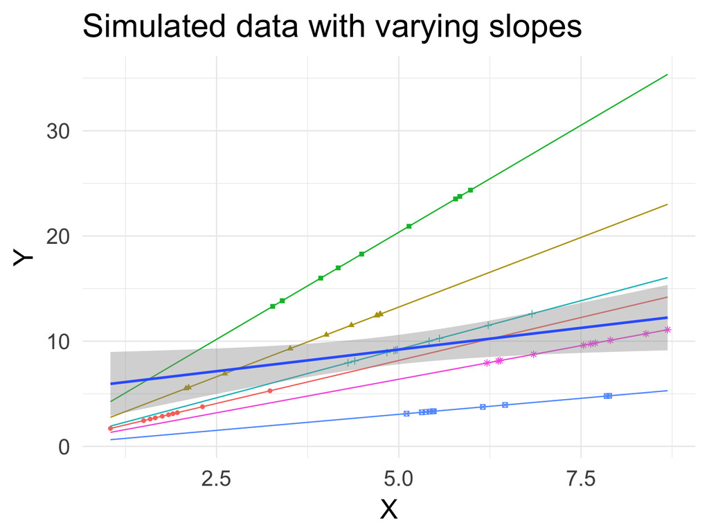

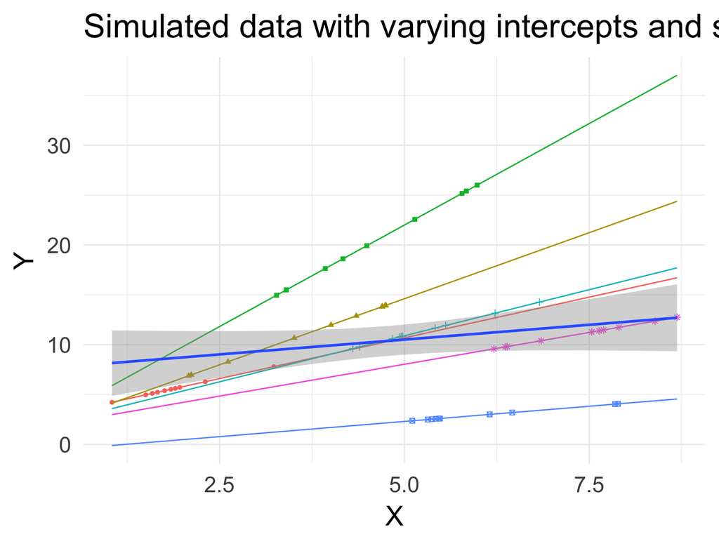

# Varying slopes with group-level predictors

$$\begin{align}
y_i &\sim N(\alpha_{j[i]} + \beta_{j[i]} x_{i}, \sigma^2_{y}), \: \text{for} \: i=1,\dotsc,n, \nonumber \\
\begin{pmatrix}
\alpha_{j} \\
\beta_{j} \\
\end{pmatrix} &\sim N\left(\begin{pmatrix}
\gamma^{\alpha}_{0} + \gamma^{\alpha}_{1} u_{j} \\
\gamma^{\beta}_{0} + \gamma^{\beta}_{1} u_{j} \\
\end{pmatrix},\begin{pmatrix}
\sigma^2_{\alpha} & \rho \sigma_{\alpha} \sigma_{\beta} \\
\rho \sigma_{\alpha} \sigma_{\beta} & \sigma^{2}_{\beta} & \\
\end{pmatrix}\right), \: \text{for} \: j=1,\dotsc,J,
\end{align}$$

# Other specifications of MLM

- Three or more levels of data
- Repeated measures (i.e. panel data)
- Time-series cross sections
- Non-nested structures
- Varying slopes without varying intercepts
- Cross-level interactions
- Discrete and non-normally distributed outcomes
- Bayesian estimation procedures
- Measuring sample size and power calculations
- Multilevel regression, imputation, and post-stratification (MRP)

# Partisan defection

$$\begin{align}
Pr(Y_{ei} = 1) &= \text{logit}^{-1}[\alpha + \beta_{1}\text{PID Intensity}_{ei} + \beta_{2}{\text{Relative Favorability}_{ei}} \nonumber \\
&\: + \beta_{3}\text{Defect is Correct}_{ei} + \beta_{4}\text{Incumbent Candidate}_{e}] \nonumber \\
\text{logit}^{-1}[x] &= \frac{e^x}{1+e^x}
\end{align}$$

# Classical logistic regression

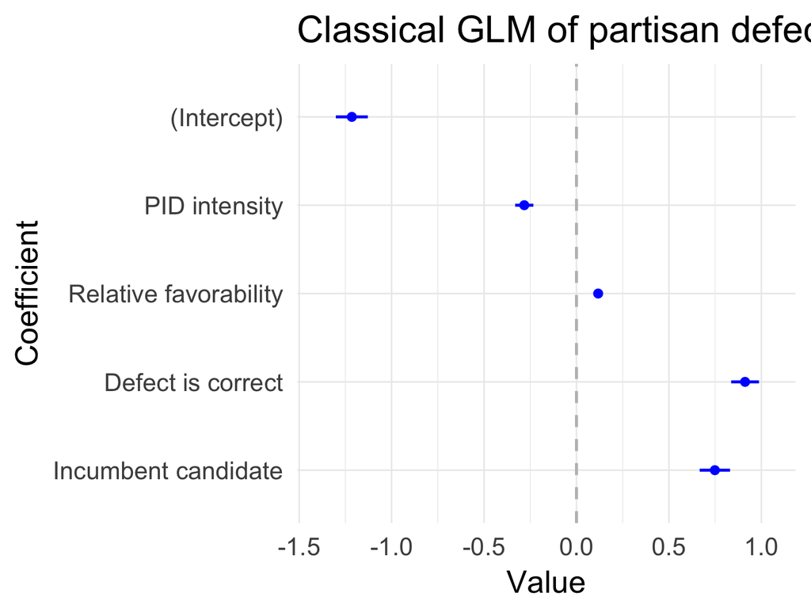

# Varying intercept

# Varying intercept

```
##                  term estimate std.error statistic   p.value group
## 1         (Intercept)   -1.197   0.21768     -5.50  3.86e-08 fixed
## 2             pid_abs   -0.288   0.04988     -5.77  8.04e-09 fixed
## 3            feel_def    0.121   0.00323     37.33 5.60e-305 fixed
## 4          defect_cor    0.850   0.07804     10.89  1.27e-27 fixed
## 5                 inc    0.640   0.25284      2.53  1.13e-02 fixed
## 6 sd_(Intercept).year    0.345        NA        NA        NA  year
```

```
## Generalized linear mixed model fit by maximum likelihood (Laplace
##   Approximation) [glmerMod]
##  Family: binomial  ( logit )
## Formula: defect ~ pid_abs + feel_def + defect_cor + inc + (1 | year)
##    Data: anes
##
##      AIC      BIC   logLik deviance df.resid
##     5209     5253    -2598     5197    10375
##
## Scaled residuals:
##     Min      1Q  Median      3Q     Max
## -11.315  -0.295  -0.135  -0.046  22.703
##
## Random effects:
##  Groups Name        Variance Std.Dev.
##  year   (Intercept) 0.119    0.345
## Number of obs: 10381, groups:  year, 10
##
## Fixed effects:
##             Estimate Std. Error z value Pr(>|z|)
## (Intercept) -1.19665    0.21768    -5.5  3.9e-08 ***
## pid_abs     -0.28768    0.04988    -5.8  8.0e-09 ***
## feel_def     0.12072    0.00323    37.3  < 2e-16 ***
## defect_cor   0.85002    0.07804    10.9  < 2e-16 ***
## inc          0.64021    0.25284     2.5    0.011 *
## ---
## Signif. codes:  0 '***' 0.001 '**' 0.01 '*' 0.05 '.' 0.1 ' ' 1
##
## Correlation of Fixed Effects:
##            (Intr) pid_bs fel_df dfct_c
## pid_abs    -0.206
## feel_def    0.039  0.012
## defect_cor -0.143  0.178 -0.062
## inc        -0.808 -0.011  0.025 -0.024
```

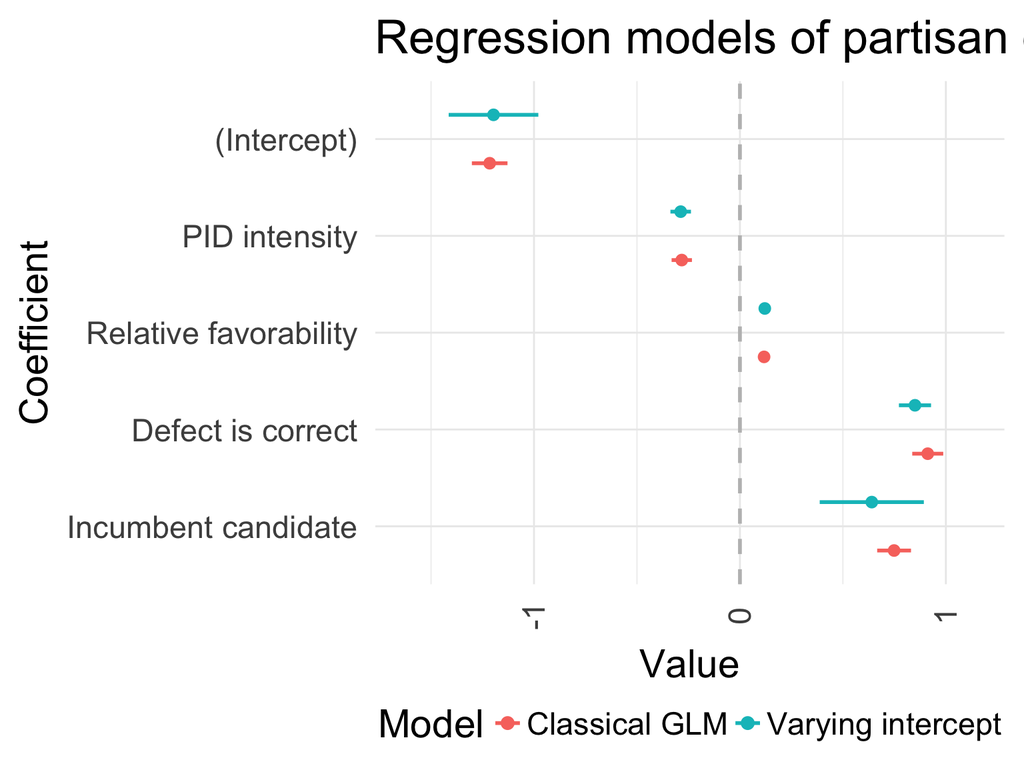

# Group-specific parameters

```
## $year
##      (Intercept) pid_abs feel_def defect_cor  inc
## 1972      -1.271  -0.288    0.121       0.85 0.64
## 1976      -1.570  -0.288    0.121       0.85 0.64
## 1980      -0.976  -0.288    0.121       0.85 0.64
## 1984      -1.423  -0.288    0.121       0.85 0.64
## 1988      -0.943  -0.288    0.121       0.85 0.64
## 1992      -0.455  -0.288    0.121       0.85 0.64
## 1996      -1.080  -0.288    0.121       0.85 0.64
## 2000      -1.329  -0.288    0.121       0.85 0.64
## 2004      -1.587  -0.288    0.121       0.85 0.64
## 2008      -1.308  -0.288    0.121       0.85 0.64
##
## attr(,"class")
## [1] "coef.mer"
```

# Varying slope(s) and intercept

- When to use varying slopes
- Log-likelihood (ANOVA) test

```
##              term df  AIC  BIC logLik deviance statistic Chi.Df p.value
## 1          defect  6 5209 5253  -2599     5197        NA     NA      NA
## 2 defect.pid3.rc1  9 5214 5280  -2598     5196     0.626      3    0.89
```

# Final model

$$\begin{align}
Pr(Y_{ei} = 1) &= \text{logit}^{-1}[\alpha_{e[i]} + \beta_{1}\text{PID Intensity}_{ei} \nonumber \\
&\quad + \beta_{2e[i]}{\text{Relative Favorability}_{ei}} + \beta_{3}\text{Defect is Correct}_{ei}] \nonumber \\
\begin{pmatrix}
\alpha_{e} \\
\beta_{2e} \\
\end{pmatrix} &\sim N\left(\begin{pmatrix}
\gamma_{0}^{\alpha} + \gamma_{1}^{\alpha}\text{Incumbent} \\
\gamma_{0}^{\beta_{2}} \\
\end{pmatrix},\begin{pmatrix}
\sigma^2_{\alpha} & \rho\sigma_{\alpha}\sigma_{\beta_2} \\
\rho\sigma_{\alpha}\sigma_{\beta_2} & \sigma^{2}_{\beta_2} \\
\end{pmatrix}\right) \nonumber \\
\text{logit}^{-1}[x] &= \frac{e^x}{1+e^x}
\end{align}$$

```
##                              term estimate std.error statistic  p.value
## 1                     (Intercept)  -1.0123   0.14373     -7.04 1.88e-12
## 2                         pid_abs  -0.2967   0.04991     -5.94 2.78e-09
## 3                        feel_def   0.1286   0.00734     17.54 7.36e-69
## 4                      defect_cor   0.8230   0.07759     10.61 2.77e-26
## 5                             inc   0.3941   0.14674      2.69 7.24e-03
## 6             sd_(Intercept).year   0.0000        NA        NA       NA
## 7           sd_(Intercept).year.1   0.2534        NA        NA       NA
## 8              sd_feel_def.year.1   0.0202        NA        NA       NA
## 9 cor_(Intercept).feel_def.year.1  -1.0000        NA        NA       NA
##    group
## 1  fixed
## 2  fixed
## 3  fixed
## 4  fixed
## 5  fixed
## 6   year
## 7 year.1
## 8 year.1
## 9 year.1
```

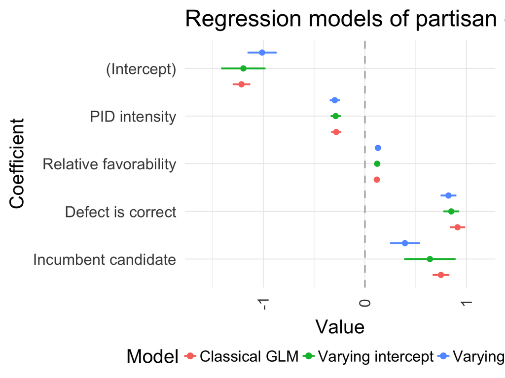

```
## $year
##      (Intercept) pid_abs feel_def defect_cor   inc
## 1972       -1.01  -0.297   0.1248      0.823 0.394
## 1976       -1.01  -0.297   0.1458      0.823 0.394
## 1980       -1.01  -0.297   0.1075      0.823 0.394
## 1984       -1.01  -0.297   0.1439      0.823 0.394
## 1988       -1.01  -0.297   0.1270      0.823 0.394
## 1992       -1.01  -0.297   0.0861      0.823 0.394
## 1996       -1.01  -0.297   0.1167      0.823 0.394
## 2000       -1.01  -0.297   0.1419      0.823 0.394
## 2004       -1.01  -0.297   0.1419      0.823 0.394
## 2008       -1.01  -0.297   0.1471      0.823 0.394
##
## attr(,"class")
## [1] "coef.mer"
```

# Varying slope uncertainty

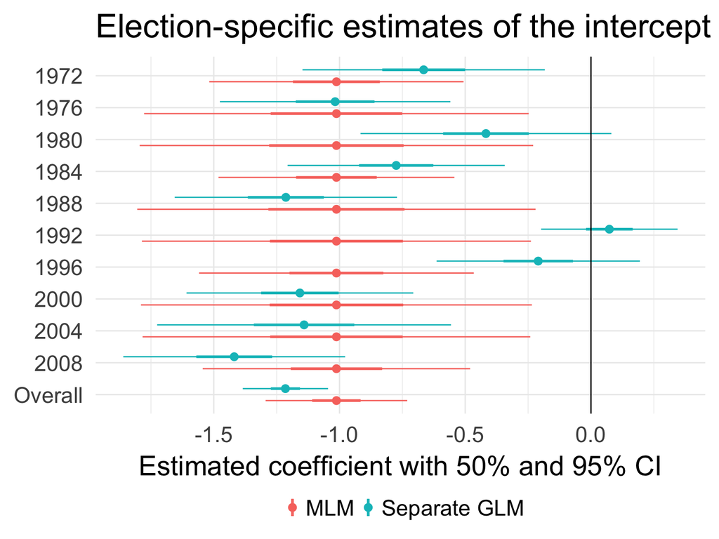

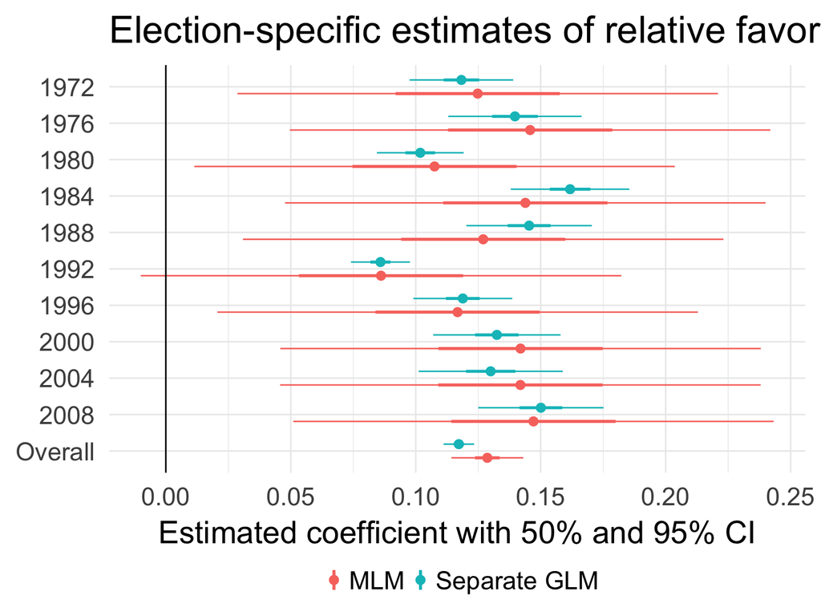

# Limitations of MLM

- Likelihood maximization (MLE)
  - Linear vs. non-linear model
  - Restricted estimation of maximum likelihood
- Bayesian estimation procedures
- Determining which coefficients should receive varying slopes